# Jobin Joseph NLPHW6 new

#### 2. Now evaluate using a major search engine.

a. Enter one of the book titles from question 1a into Google, Bing, or Yahoo!. Copy the capsule of the first organic result and the 20th organic result. Take web results only (i.e., not video results), and skip sponsored results. b. Run the same text similarity calculation that you used for question 1b on each of these capsules in comparison to the original query (book title). c. Which one has the highest similarity measure?

```python
Firstgoogle_result = [
    "Stunning Digital Photography - Tony & Chelsea Northrup",
    "stunning digital photography"
]

twentiethgoogle_result = [
    "stunning digital photography",
    "Learn to Take Stunning Digital Images Every Time"

]
```

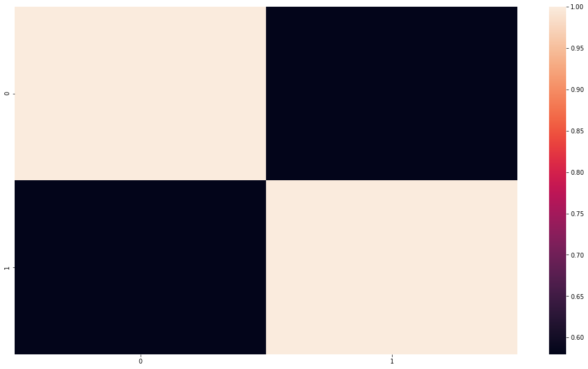

|  | 0 | 1 |
| --- | --- | --- |
| 0 | 1.000000 | 0.579739 |
| 1 | 0.579739 | 1.000000 |

```python
compare_titles(Firstgoogle_result)
```

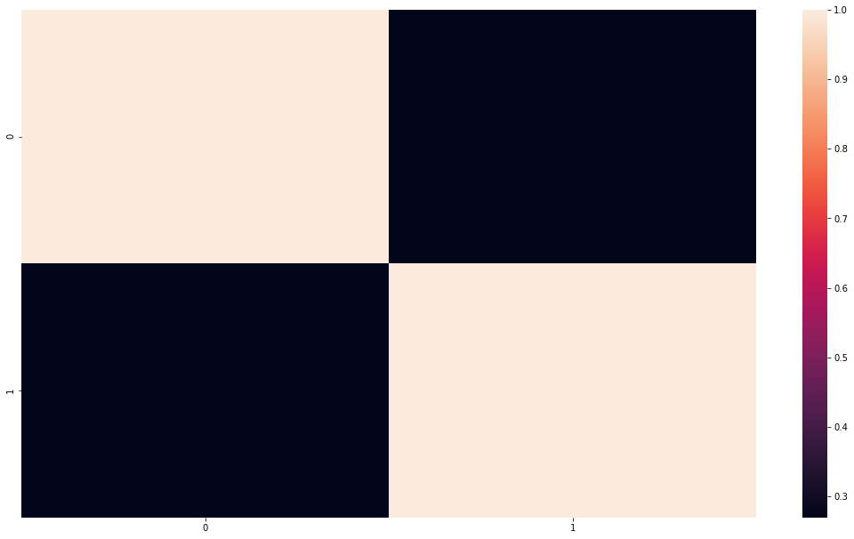

|  | 0 | 1 |
| --- | --- | --- |
| 0 | 1.000000 | 0.269518 |
| 1 | 0.269518 | 1.000000 |

```python
compare_titles(twentiethgoogle_result)
```